# multi-class-classification-Keras-KerasTuner-2

**Hyperparameter optimization for neural networks using Keras-Tuner (example: multi-class classification with numerical Data)**

**Hyperparameter optimization** There are two approaches for HP optimization:

- Sequencial approach
- Combination between all HPS

**Hyperparameters (Search Space)**  
There are 2 types of hyperparameters. Model specific HPs that define the NN model. And training specific HPs that are used to optimize/guarantee trade off between generalization and overfitting a specific model for model evaluation.

- Number of layers
- Number of neurons in each layer

**Keras-Tuner**

- https://www.curiousily.com/posts/hackers-guide-to-hyperparameter-tuning/
- https://www.sicara.ai/blog/hyperparameter-tuning-keras-tuner
- https://pythonprogramming.net/keras-tuner-optimizing-neural-network-tutorial/ / https://www.youtube.com/watch?v=vvC15l4CY1Q

**Using Scikit Learn Wrapper for Hyperparameter Tuning**

- https://www.youtube.com/watch?v=0AJECUm8gY0
- https://machinelearningmastery.com/grid-search-hyperparameters-deep-learning-models-python-keras/

```python
import numpy as np
import pandas as pd
import matplotlib.pyplot as plt

from tensorflow import keras
from keras.models import Sequential
from keras.layers import Dense, Dropout
from keras.wrappers.scikit_learn import KerasClassifier
from keras.utils import np_utils

from sklearn.model_selection import cross_val_score
from sklearn.model_selection import KFold
from sklearn.preprocessing import LabelEncoder
from sklearn.pipeline import Pipeline

from sklearn.datasets import load_iris
```

# Data preprocessing

## Load Iris Dataset

```python
# Load Data
data = load_iris()
features = np.array(data.data)
labels = np.array(data.target)

# load dataset
#dataframe = pandas.read_csv("iris.csv", header=None)
#dataset = dataframe.values
#X = dataset[:,0:4].astype(float)
#Y = dataset[:,4]
```

```python
df = pd.DataFrame(features)
```

```python
df.head()
```

|  | 0 | 1 | 2 | 3 |
| --- | --- | --- | --- | --- |
| 0 | 5.1 | 3.5 | 1.4 | 0.2 |
| 1 | 4.9 | 3.0 | 1.4 | 0.2 |
| 2 | 4.7 | 3.2 | 1.3 | 0.2 |
| 3 | 4.6 | 3.1 | 1.5 | 0.2 |
| 4 | 5.0 | 3.6 | 1.4 | 0.2 |

```python
df.describe()
```

|  | 0 | 1 | 2 | 3 |
| --- | --- | --- | --- | --- |
| count | 150.000000 | 150.000000 | 150.000000 | 150.000000 |
| mean | 5.843333 | 3.057333 | 3.758000 | 1.199333 |
| std | 0.828066 | 0.435866 | 1.765298 | 0.762238 |
| min | 4.300000 | 2.000000 | 1.000000 | 0.100000 |
| 25% | 5.100000 | 2.800000 | 1.600000 | 0.300000 |
| 50% | 5.800000 | 3.000000 | 4.350000 | 1.300000 |
| 75% | 6.400000 | 3.300000 | 5.100000 | 1.800000 |
| max | 7.900000 | 4.400000 | 6.900000 | 2.500000 |

```python
df2 = pd.DataFrame(labels)
```

```python
df2.head()
```

|  | 0 |
| --- | --- |
| 0 | 0 |
| 1 | 0 |
| 2 | 0 |
| 3 | 0 |
| 4 | 0 |

```python
df2.describe()
```

|  | 0 |
| --- | --- |
| count | 150.000000 |
| mean | 1.000000 |
| std | 0.819232 |
| min | 0.000000 |
| 25% | 0.000000 |
| 50% | 1.000000 |
| 75% | 2.000000 |
| max | 2.000000 |

```python
X=features
Y=labels
```

## Encode labels

```python
# encode class values as integers
encoder = LabelEncoder()
encoder.fit(Y)
encoded_Y = encoder.transform(Y)
# convert integers to dummy variables (i.e. one hot encoded)
dummy_y = np_utils.to_categorical(encoded_Y)
```

## Train-/Test-Split

```python
# Split data in train and test
from sklearn.model_selection import train_test_split
# slit data
X_train, X_test, y_train, y_test = train_test_split(X, dummy_y, test_size=0.3, random_state=1)
```

# Hyperparameter optimization using Keras-Tuner

```python
import kerastuner
from kerastuner.tuners import RandomSearch
from kerastuner.engine.hyperparameters import HyperParameters
kerastuner.__version__
```

```
'1.0.1'
```

```python
def tune_optimizer_model(hp):

    # HYPERPARAMETER: number of layers, +++integrated in loop+++
    #hp.Int('num_layers', min_value=1, max_value=5, step=1)

    # HYPERPARAMETER: number of neurons, +++integrated in loop+++
    #units = hp.Int('units', min_value=4, max_value=16, step=4)

    # HYPERPARAMETER: optimizer
    #optimizer = hp.Choice('optimizer', ['adam', 'sgd', 'rmsprop'])
    #optimizer = hp.Choice('optimizer', [Adam(learning_rate), 'sgd'])
    optimizer = hp.Choice('optimizer', ['adam', 'sgd'])

    # Hyperparameter: learning_rate
    #learning_rate

    # Hyperparameter: momentum
    #momentum

    # Hyperparameter: activation function
    #activation = hp.Choice('activation', ['softmax', 'softplus', 'softsign', 'relu', 'tanh', 'sigmoid', 'hard_sigmoid', 'linear'])
    activation = hp.Choice('activation', ['relu', 'sigmoid'])

    # Hyperparameter: drop out rate, +++integrated in loop+++
    #drop_rate = hp.Choice('drop_rate', [0.0, 0.1, 0.2, 0.3, 0.4, 0.5, 0.6, 0.7, 0.8, 0.9])


    # create model
    model = keras.Sequential()

    # HYPERPARAMETER: searcher for best number of layers between min_value and max_value with stepsize of step
    # LOOP NOTE: loop includes min_value and max_value (refers to hp.Int(...)), but i allways starts from 0 and goes to max_value-1
    for i in range(hp.Int('num_inner_layers', min_value=3, max_value=6, step=1)):
        # HYPERPARAMETER: Number of neurons in each layer
        units = hp.Int('units_in_layer_' + str(i+1), min_value=4, max_value=16, step=4) # +1 since its for the unique name of the i-th layer but i start with 0
        # defines input layer and searches(optimizes) for number of neurons for first layer
        if i == 0:
            model.add(keras.layers.Dense(units=units,
                                         activation=activation,
                                         input_shape=[X_train.shape[1]]))
        # define all but not first layer
        else:
            model.add(keras.layers.Dense(units=units,
                                         activation=activation))
        # HYPERPARAMETER: drop out rate for each layer
        drop_rate = hp.Choice('drop_rate_in_layer_' + str(i+1), [0.0, 0.2]) # +1 since its for the unique name of the i-th layer but i start with 0
        model.add(keras.layers.Dropout(rate=drop_rate))
    # define outputlayer
    model.add(keras.layers.Dense(3, activation='softmax')) # softmax for final prediction

    # Compile model
    model.compile(optimizer=optimizer,
                  loss = 'categorical_crossentropy',
                  metrics = ['accuracy'])

    return model
```

```python
# create and configure tuner

# Directory to save logs
import time
LOG_DIR = 'log_keras-tuner_' + f"{int(time.time())}"

# random seed
random_seed = 1

# define the tuner
tuner = RandomSearch(
            tune_optimizer_model,
            objective='val_accuracy',
            # number of modelvariations to test
            max_trials=50,
            # how many trials per model variation (same model could perform differently)
            executions_per_trial=1,
            directory=LOG_DIR,
            #project_name='tune_optimizer',
            seed=random_seed
            )
```

```python
# get a summary of the different parameter values from our Tuner, NOTE: only gives back the summary for the NN with min number of layers!
search_space_summary = tuner.search_space_summary()
search_space_summary
```

Search space summary

|-Default search space size: 9

optimizer (Choice)

|-default: adam

|-ordered: False

|-values: ['adam', 'sgd']

activation (Choice)

|-default: relu

|-ordered: False

|-values: ['relu', 'sigmoid']

[output not shown]

|-max_value: 6

|-min_value: 3

|-sampling: None

|-step: 1

units_in_layer_1 (Int)

|-default: None

|-max_value: 16

|-min_value: 4

|-sampling: None

|-step: 4

drop_rate_in_layer_1 (Choice)

|-default: 0.0

|-ordered: True

|-values: [0.0, 0.2]

units_in_layer_2 (Int)

|-default: None

|-max_value: 16

|-min_value: 4

|-sampling: None

|-step: 4

drop_rate_in_layer_2 (Choice)

|-default: 0.0

|-ordered: True

|-values: [0.0, 0.2]

units_in_layer_3 (Int)

|-default: None

|-max_value: 16

|-min_value: 4

|-sampling: None

|-step: 4

drop_rate_in_layer_3 (Choice)

|-default: 0.0

|-ordered: True

|-values: [0.0, 0.2]

```python
# start the optimization
tuner.search(x=X_train,
             y=y_train,
             epochs=40,
             batch_size=10,
             validation_data=(X_test, y_test),
             verbose=0
             )
```

Trial complete

Trial summary

|-Trial ID: b258cf5b6351fb676bf848f766ca8093

|-Score: 0.7111111283302307

|-Best step: 0

Hyperparameters:

|-activation: relu

|-drop_rate_in_layer_1: 0.2

|-drop_rate_in_layer_2: 0.2

|-drop_rate_in_layer_3: 0.2

|-drop_rate_in_layer_4: 0.0

|-num_inner_layers: 4

|-optimizer: adam

|-units_in_layer_1: 8

|-units_in_layer_2: 12

|-units_in_layer_3: 8

|-units_in_layer_4: 4

Trial complete

Trial summary

|-Trial ID: 12bea57ca2637c5e9f052a7def9586ca

|-Score: 0.6000000238418579

|-Best step: 0

Hyperparameters:

|-activation: sigmoid

|-drop_rate_in_layer_1: 0.0

|-drop_rate_in_layer_2: 0.2

|-drop_rate_in_layer_3: 0.0

|-drop_rate_in_layer_4: 0.0

|-num_inner_layers: 4

|-optimizer: adam

|-units_in_layer_1: 8

|-units_in_layer_2: 16

|-units_in_layer_3: 12

|-units_in_layer_4: 12

Trial complete

Trial summary

|-Trial ID: b0630ccfd8df3f1cfe7d0da2d5c9e53d

|-Score: 0.6000000238418579

|-Best step: 0

Hyperparameters:

|-activation: relu

|-drop_rate_in_layer_1: 0.2

|-drop_rate_in_layer_2: 0.2

|-drop_rate_in_layer_3: 0.0

|-drop_rate_in_layer_4: 0.0

|-drop_rate_in_layer_5: 0.0

|-drop_rate_in_layer_6: 0.0

|-num_inner_layers: 6

|-optimizer: adam

|-units_in_layer_1: 12

|-units_in_layer_2: 12

|-units_in_layer_3: 4

|-units_in_layer_4: 12

|-units_in_layer_5: 4

|-units_in_layer_6: 4

Trial complete

Trial summary

|-Trial ID: cc4685ac342b2c59c4182465a0d8a1e7

|-Score: 0.6000000238418579

|-Best step: 0

Hyperparameters:

|-activation: relu

|-drop_rate_in_layer_1: 0.2

|-drop_rate_in_layer_2: 0.2

|-drop_rate_in_layer_3: 0.2

|-drop_rate_in_layer_4: 0.0

|-drop_rate_in_layer_5: 0.2

|-drop_rate_in_layer_6: 0.0

|-num_inner_layers: 5

|-optimizer: adam

|-units_in_layer_1: 12

|-units_in_layer_2: 12

|-units_in_layer_3: 8

|-units_in_layer_4: 8

|-units_in_layer_5: 4

|-units_in_layer_6: 8

Trial complete

Trial summary

|-Trial ID: 3887879bec24eccb18eb8bb0a3b9e9ea

|-Score: 0.6000000238418579

|-Best step: 0

Hyperparameters:

|-activation: sigmoid

|-drop_rate_in_layer_1: 0.0

|-drop_rate_in_layer_2: 0.0

|-drop_rate_in_layer_3: 0.0

|-drop_rate_in_layer_4: 0.0

|-drop_rate_in_layer_5: 0.0

|-drop_rate_in_layer_6: 0.2

|-num_inner_layers: 3

|-optimizer: sgd

|-units_in_layer_1: 8

|-units_in_layer_2: 16

|-units_in_layer_3: 16

|-units_in_layer_4: 16

|-units_in_layer_5: 12

|-units_in_layer_6: 8

Trial complete

Trial summary

|-Trial ID: 0f3000a0e78f8f01ae022d0c65bfbb87

|-Score: 0.4000000059604645

|-Best step: 0

Hyperparameters:

|-activation: sigmoid

|-drop_rate_in_layer_1: 0.0

|-drop_rate_in_layer_2: 0.2

|-drop_rate_in_layer_3: 0.0

|-drop_rate_in_layer_4: 0.0

|-drop_rate_in_layer_5: 0.0

|-drop_rate_in_layer_6: 0.2

|-num_inner_layers: 4

|-optimizer: adam

|-units_in_layer_1: 8

|-units_in_layer_2: 4

|-units_in_layer_3: 12

|-units_in_layer_4: 8

|-units_in_layer_5: 8

|-units_in_layer_6: 8

Trial complete

Trial summary

|-Trial ID: 47932c09b73fce55db913f5c0e19963c

|-Score: 0.6000000238418579

|-Best step: 0

Hyperparameters:

|-activation: relu

|-drop_rate_in_layer_1: 0.2

|-drop_rate_in_layer_2: 0.2

|-drop_rate_in_layer_3: 0.0

|-drop_rate_in_layer_4: 0.0

|-drop_rate_in_layer_5: 0.0

|-drop_rate_in_layer_6: 0.0

|-num_inner_layers: 3

|-optimizer: sgd

|-units_in_layer_1: 8

|-units_in_layer_2: 4

|-units_in_layer_3: 12

|-units_in_layer_4: 12

|-units_in_layer_5: 8

|-units_in_layer_6: 8

Trial complete

Trial summary

|-Trial ID: d19780f355499a2b2c86d2b3c1b5f2f6

|-Score: 0.31111112236976624

|-Best step: 0

Hyperparameters:

|-activation: sigmoid

|-drop_rate_in_layer_1: 0.2

|-drop_rate_in_layer_2: 0.2

|-drop_rate_in_layer_3: 0.0

|-drop_rate_in_layer_4: 0.0

|-drop_rate_in_layer_5: 0.0

|-drop_rate_in_layer_6: 0.2

|-num_inner_layers: 5

|-optimizer: sgd

|-units_in_layer_1: 12

|-units_in_layer_2: 8

|-units_in_layer_3: 8

|-units_in_layer_4: 12

|-units_in_layer_5: 16

|-units_in_layer_6: 16

Trial complete

Trial summary

|-Trial ID: 0a2d8503f4f30c7f2c2243fa99194fd3

|-Score: 1.0

|-Best step: 0

Hyperparameters:

|-activation: relu

|-drop_rate_in_layer_1: 0.0

|-drop_rate_in_layer_2: 0.0

|-drop_rate_in_layer_3: 0.2

|-drop_rate_in_layer_4: 0.0

|-drop_rate_in_layer_5: 0.2

|-drop_rate_in_layer_6: 0.0

|-num_inner_layers: 4

|-optimizer: adam

|-units_in_layer_1: 16

|-units_in_layer_2: 8

|-units_in_layer_3: 8

|-units_in_layer_4: 12

|-units_in_layer_5: 12

|-units_in_layer_6: 12

Trial complete

Trial summary

|-Trial ID: b93f8befcd3e9500f86eb1c9bcc28c5a

|-Score: 0.6222222447395325

|-Best step: 0

Hyperparameters:

|-activation: relu

|-drop_rate_in_layer_1: 0.0

|-drop_rate_in_layer_2: 0.0

|-drop_rate_in_layer_3: 0.2

|-drop_rate_in_layer_4: 0.2

|-drop_rate_in_layer_5: 0.2

|-drop_rate_in_layer_6: 0.2

|-num_inner_layers: 6

|-optimizer: adam

|-units_in_layer_1: 16

|-units_in_layer_2: 4

|-units_in_layer_3: 12

|-units_in_layer_4: 8

|-units_in_layer_5: 8

|-units_in_layer_6: 12

Trial complete

Trial summary

|-Trial ID: 12fae92b214d45fef5fef66ff142a4fe

|-Score: 0.8888888955116272

|-Best step: 0

Hyperparameters:

|-activation: relu

|-drop_rate_in_layer_1: 0.0

|-drop_rate_in_layer_2: 0.0

|-drop_rate_in_layer_3: 0.2

|-drop_rate_in_layer_4: 0.0

|-drop_rate_in_layer_5: 0.0

|-drop_rate_in_layer_6: 0.2

|-num_inner_layers: 3

|-optimizer: adam

|-units_in_layer_1: 12

|-units_in_layer_2: 12

|-units_in_layer_3: 8

|-units_in_layer_4: 4

|-units_in_layer_5: 8

|-units_in_layer_6: 12

Trial complete

Trial summary

|-Trial ID: 45bae2fcc0dbaa94447c273aa64247dc

|-Score: 0.4000000059604645

|-Best step: 0

Hyperparameters:

|-activation: sigmoid

|-drop_rate_in_layer_1: 0.2

|-drop_rate_in_layer_2: 0.0

|-drop_rate_in_layer_3: 0.0

|-drop_rate_in_layer_4: 0.0

|-drop_rate_in_layer_5: 0.0

|-drop_rate_in_layer_6: 0.0

|-num_inner_layers: 4

|-optimizer: sgd

|-units_in_layer_1: 12

|-units_in_layer_2: 12

|-units_in_layer_3: 8

|-units_in_layer_4: 12

|-units_in_layer_5: 12

|-units_in_layer_6: 4

Trial complete

Trial summary

|-Trial ID: 54333539f61a6e30a1c901cad26ddd58

|-Score: 0.6888889074325562

|-Best step: 0

Hyperparameters:

|-activation: relu

|-drop_rate_in_layer_1: 0.2

|-drop_rate_in_layer_2: 0.2

|-drop_rate_in_layer_3: 0.2

|-drop_rate_in_layer_4: 0.0

|-drop_rate_in_layer_5: 0.0

|-drop_rate_in_layer_6: 0.0

|-num_inner_layers: 4

|-optimizer: adam

|-units_in_layer_1: 12

|-units_in_layer_2: 8

|-units_in_layer_3: 12

|-units_in_layer_4: 4

|-units_in_layer_5: 16

|-units_in_layer_6: 4

Trial complete

Trial summary

|-Trial ID: 86b02d80f6ee48834e4e59f630aca260

|-Score: 0.9777777791023254

|-Best step: 0

Hyperparameters:

|-activation: relu

|-drop_rate_in_layer_1: 0.2

|-drop_rate_in_layer_2: 0.0

|-drop_rate_in_layer_3: 0.0

|-drop_rate_in_layer_4: 0.2

|-drop_rate_in_layer_5: 0.0

|-drop_rate_in_layer_6: 0.0

|-num_inner_layers: 4

|-optimizer: sgd

|-units_in_layer_1: 16

|-units_in_layer_2: 8

|-units_in_layer_3: 8

|-units_in_layer_4: 12

|-units_in_layer_5: 12

|-units_in_layer_6: 12

Trial complete

Trial summary

|-Trial ID: 07f0b1e389a99b694de88e51cac5752e

|-Score: 0.4000000059604645

|-Best step: 0

Hyperparameters:

|-activation: relu

|-drop_rate_in_layer_1: 0.0

|-drop_rate_in_layer_2: 0.0

|-drop_rate_in_layer_3: 0.2

|-drop_rate_in_layer_4: 0.0

|-drop_rate_in_layer_5: 0.0

|-drop_rate_in_layer_6: 0.2

|-num_inner_layers: 4

|-optimizer: adam

|-units_in_layer_1: 4

|-units_in_layer_2: 12

|-units_in_layer_3: 8

|-units_in_layer_4: 4

|-units_in_layer_5: 8

|-units_in_layer_6: 8

Trial complete

Trial summary

|-Trial ID: 9ffbd004c5a0555b07dc96f58f1f6f6f

|-Score: 1.0

|-Best step: 0

Hyperparameters:

|-activation: relu

|-drop_rate_in_layer_1: 0.0

|-drop_rate_in_layer_2: 0.2

|-drop_rate_in_layer_3: 0.0

|-drop_rate_in_layer_4: 0.0

|-drop_rate_in_layer_5: 0.0

|-drop_rate_in_layer_6: 0.2

|-num_inner_layers: 5

|-optimizer: sgd

|-units_in_layer_1: 4

|-units_in_layer_2: 16

|-units_in_layer_3: 12

|-units_in_layer_4: 8

|-units_in_layer_5: 8

|-units_in_layer_6: 12

Trial complete

Trial summary

|-Trial ID: 729e0d54cbe6023c680dcfef4df507a5

|-Score: 0.6222222447395325

|-Best step: 0

Hyperparameters:

|-activation: relu

|-drop_rate_in_layer_1: 0.0

|-drop_rate_in_layer_2: 0.0

|-drop_rate_in_layer_3: 0.2

|-drop_rate_in_layer_4: 0.2

|-drop_rate_in_layer_5: 0.0

|-drop_rate_in_layer_6: 0.0

|-num_inner_layers: 5

|-optimizer: sgd

|-units_in_layer_1: 12

|-units_in_layer_2: 8

|-units_in_layer_3: 8

|-units_in_layer_4: 12

|-units_in_layer_5: 12

|-units_in_layer_6: 16

Trial complete

Trial summary

|-Trial ID: 2fb2f0f1422e1f1fc109a3c3337204d8

|-Score: 0.4000000059604645

|-Best step: 0

Hyperparameters:

|-activation: sigmoid

|-drop_rate_in_layer_1: 0.0

|-drop_rate_in_layer_2: 0.2

|-drop_rate_in_layer_3: 0.2

|-drop_rate_in_layer_4: 0.0

|-drop_rate_in_layer_5: 0.2

|-drop_rate_in_layer_6: 0.2

|-num_inner_layers: 6

|-optimizer: sgd

|-units_in_layer_1: 4

|-units_in_layer_2: 8

|-units_in_layer_3: 8

|-units_in_layer_4: 8

|-units_in_layer_5: 12

|-units_in_layer_6: 4

Trial complete

Trial summary

|-Trial ID: 4504403798e9be42f4b0ae105983105e

|-Score: 0.800000011920929

|-Best step: 0

Hyperparameters:

|-activation: relu

|-drop_rate_in_layer_1: 0.2

|-drop_rate_in_layer_2: 0.2

|-drop_rate_in_layer_3: 0.2

|-drop_rate_in_layer_4: 0.0

|-drop_rate_in_layer_5: 0.0

|-drop_rate_in_layer_6: 0.2

|-num_inner_layers: 3

|-optimizer: sgd

|-units_in_layer_1: 8

|-units_in_layer_2: 8

|-units_in_layer_3: 12

|-units_in_layer_4: 16

|-units_in_layer_5: 12

|-units_in_layer_6: 16

Trial complete

Trial summary

|-Trial ID: 6378803e2582c6522d0ac3e0704b7160

|-Score: 0.9777777791023254

|-Best step: 0

Hyperparameters:

|-activation: relu

|-drop_rate_in_layer_1: 0.2

|-drop_rate_in_layer_2: 0.2

|-drop_rate_in_layer_3: 0.2

|-drop_rate_in_layer_4: 0.0

|-drop_rate_in_layer_5: 0.0

|-drop_rate_in_layer_6: 0.2

|-num_inner_layers: 3

|-optimizer: sgd

|-units_in_layer_1: 12

|-units_in_layer_2: 16

|-units_in_layer_3: 8

|-units_in_layer_4: 4

|-units_in_layer_5: 12

|-units_in_layer_6: 12

Trial complete

Trial summary

|-Trial ID: b52509cad5329114c7eac12a63a318ec

|-Score: 0.31111112236976624

|-Best step: 0

Hyperparameters:

|-activation: sigmoid

|-drop_rate_in_layer_1: 0.2

|-drop_rate_in_layer_2: 0.2

|-drop_rate_in_layer_3: 0.2

|-drop_rate_in_layer_4: 0.2

|-drop_rate_in_layer_5: 0.2

|-drop_rate_in_layer_6: 0.2

|-num_inner_layers: 6

|-optimizer: adam

|-units_in_layer_1: 12

|-units_in_layer_2: 12

|-units_in_layer_3: 8

|-units_in_layer_4: 4

|-units_in_layer_5: 8

|-units_in_layer_6: 12

Trial complete

Trial summary

|-Trial ID: 55e1a5b0c2e96fc7562cce7b12c4bf4e

|-Score: 0.7555555701255798

|-Best step: 0

Hyperparameters:

|-activation: relu

|-drop_rate_in_layer_1: 0.2

|-drop_rate_in_layer_2: 0.0

|-drop_rate_in_layer_3: 0.0

|-drop_rate_in_layer_4: 0.0

|-drop_rate_in_layer_5: 0.0

|-drop_rate_in_layer_6: 0.0

|-num_inner_layers: 3

|-optimizer: sgd

|-units_in_layer_1: 8

|-units_in_layer_2: 12

|-units_in_layer_3: 4

|-units_in_layer_4: 12

|-units_in_layer_5: 12

|-units_in_layer_6: 8

Trial complete

Trial summary

|-Trial ID: 523932e06501b48db86e7f73f11a79b6

|-Score: 0.8888888955116272

|-Best step: 0

Hyperparameters:

|-activation: relu

|-drop_rate_in_layer_1: 0.2

|-drop_rate_in_layer_2: 0.0

|-drop_rate_in_layer_3: 0.0

|-drop_rate_in_layer_4: 0.0

|-drop_rate_in_layer_5: 0.2

|-drop_rate_in_layer_6: 0.2

|-num_inner_layers: 4

|-optimizer: sgd

|-units_in_layer_1: 8

|-units_in_layer_2: 16

|-units_in_layer_3: 12

|-units_in_layer_4: 4

|-units_in_layer_5: 12

|-units_in_layer_6: 16

Trial complete

Trial summary

|-Trial ID: 0399e83128ecec6b516af2df4076668c

|-Score: 0.46666666865348816

|-Best step: 0

Hyperparameters:

|-activation: sigmoid

|-drop_rate_in_layer_1: 0.0

|-drop_rate_in_layer_2: 0.0

|-drop_rate_in_layer_3: 0.2

|-drop_rate_in_layer_4: 0.0

|-drop_rate_in_layer_5: 0.2

|-drop_rate_in_layer_6: 0.0

|-num_inner_layers: 6

|-optimizer: adam

|-units_in_layer_1: 4

|-units_in_layer_2: 8

|-units_in_layer_3: 4

|-units_in_layer_4: 12

|-units_in_layer_5: 8

|-units_in_layer_6: 12

Trial complete

Trial summary

|-Trial ID: 678a9369eeaeac530d264da74fee74d9

|-Score: 0.31111112236976624

|-Best step: 0

Hyperparameters:

|-activation: sigmoid

|-drop_rate_in_layer_1: 0.2

|-drop_rate_in_layer_2: 0.0

|-drop_rate_in_layer_3: 0.0

|-drop_rate_in_layer_4: 0.0

|-drop_rate_in_layer_5: 0.0

|-drop_rate_in_layer_6: 0.0

|-num_inner_layers: 4

|-optimizer: sgd

|-units_in_layer_1: 16

|-units_in_layer_2: 16

|-units_in_layer_3: 8

|-units_in_layer_4: 12

|-units_in_layer_5: 12

|-units_in_layer_6: 16

Trial complete

Trial summary

|-Trial ID: 76d18da0d4ced96e26cd7178c6f10e4d

|-Score: 0.9111111164093018

|-Best step: 0

Hyperparameters:

|-activation: relu

|-drop_rate_in_layer_1: 0.0

|-drop_rate_in_layer_2: 0.2

|-drop_rate_in_layer_3: 0.0

|-drop_rate_in_layer_4: 0.0

|-drop_rate_in_layer_5: 0.2

|-drop_rate_in_layer_6: 0.2

|-num_inner_layers: 5

|-optimizer: sgd

|-units_in_layer_1: 12

|-units_in_layer_2: 4

|-units_in_layer_3: 12

|-units_in_layer_4: 8

|-units_in_layer_5: 4

|-units_in_layer_6: 8

Trial complete

Trial summary

|-Trial ID: 0a8ed558c411b355c6670b5285569f5c

|-Score: 0.7111111283302307

|-Best step: 0

Hyperparameters:

|-activation: relu

|-drop_rate_in_layer_1: 0.2

|-drop_rate_in_layer_2: 0.2

|-drop_rate_in_layer_3: 0.0

|-drop_rate_in_layer_4: 0.2

|-drop_rate_in_layer_5: 0.2

|-drop_rate_in_layer_6: 0.2

|-num_inner_layers: 3

|-optimizer: adam

|-units_in_layer_1: 16

|-units_in_layer_2: 4

|-units_in_layer_3: 12

|-units_in_layer_4: 12

|-units_in_layer_5: 12

|-units_in_layer_6: 12

Trial complete

Trial summary

|-Trial ID: 47caa236e8fa0dd572a0b908b42025fc

|-Score: 0.31111112236976624

|-Best step: 0

Hyperparameters:

|-activation: sigmoid

|-drop_rate_in_layer_1: 0.0

|-drop_rate_in_layer_2: 0.2

|-drop_rate_in_layer_3: 0.2

|-drop_rate_in_layer_4: 0.2

|-drop_rate_in_layer_5: 0.0

|-drop_rate_in_layer_6: 0.2

|-num_inner_layers: 6

|-optimizer: sgd

|-units_in_layer_1: 8

|-units_in_layer_2: 4

|-units_in_layer_3: 4

|-units_in_layer_4: 8

|-units_in_layer_5: 8

|-units_in_layer_6: 4

Trial complete

Trial summary

|-Trial ID: 443205564623d2bd9b566d3bdcb1721e

|-Score: 0.6000000238418579

|-Best step: 0

Hyperparameters:

|-activation: sigmoid

|-drop_rate_in_layer_1: 0.0

|-drop_rate_in_layer_2: 0.2

|-drop_rate_in_layer_3: 0.2

|-drop_rate_in_layer_4: 0.0

|-drop_rate_in_layer_5: 0.0

|-drop_rate_in_layer_6: 0.2

|-num_inner_layers: 5

|-optimizer: adam

|-units_in_layer_1: 4

|-units_in_layer_2: 8

|-units_in_layer_3: 8

|-units_in_layer_4: 8

|-units_in_layer_5: 8

|-units_in_layer_6: 4

Trial complete

Trial summary

|-Trial ID: 8cf2d57fb3685347d2504314a62006cd

|-Score: 0.4000000059604645

|-Best step: 0

Hyperparameters:

|-activation: sigmoid

|-drop_rate_in_layer_1: 0.0

|-drop_rate_in_layer_2: 0.2

|-drop_rate_in_layer_3: 0.2

|-drop_rate_in_layer_4: 0.2

|-drop_rate_in_layer_5: 0.2

|-drop_rate_in_layer_6: 0.2

|-num_inner_layers: 5

|-optimizer: sgd

|-units_in_layer_1: 8

|-units_in_layer_2: 4

|-units_in_layer_3: 12

|-units_in_layer_4: 16

|-units_in_layer_5: 8

|-units_in_layer_6: 16

Trial complete

Trial summary

|-Trial ID: 6163a0b73705a50a45ca6645408883c9

|-Score: 0.8444444537162781

|-Best step: 0

Hyperparameters:

|-activation: relu

|-drop_rate_in_layer_1: 0.0

|-drop_rate_in_layer_2: 0.0

|-drop_rate_in_layer_3: 0.2

|-drop_rate_in_layer_4: 0.2

|-drop_rate_in_layer_5: 0.0

|-drop_rate_in_layer_6: 0.0

|-num_inner_layers: 4

|-optimizer: sgd

|-units_in_layer_1: 4

|-units_in_layer_2: 8

|-units_in_layer_3: 8

|-units_in_layer_4: 12

|-units_in_layer_5: 8

|-units_in_layer_6: 4

Trial complete

Trial summary

|-Trial ID: eb983dc5329860ac9959aec8b4f47e7e

|-Score: 1.0

|-Best step: 0

Hyperparameters:

|-activation: relu

|-drop_rate_in_layer_1: 0.2

|-drop_rate_in_layer_2: 0.0

|-drop_rate_in_layer_3: 0.2

|-drop_rate_in_layer_4: 0.0

|-drop_rate_in_layer_5: 0.2

|-drop_rate_in_layer_6: 0.0

|-num_inner_layers: 4

|-optimizer: sgd

|-units_in_layer_1: 16

|-units_in_layer_2: 12

|-units_in_layer_3: 16

|-units_in_layer_4: 12

|-units_in_layer_5: 8

|-units_in_layer_6: 8

Trial complete

Trial summary

|-Trial ID: 56524e9d52b6ee98f07b70d12353714f

|-Score: 0.9111111164093018

|-Best step: 0

Hyperparameters:

|-activation: relu

|-drop_rate_in_layer_1: 0.0

|-drop_rate_in_layer_2: 0.2

|-drop_rate_in_layer_3: 0.0

|-drop_rate_in_layer_4: 0.2

|-drop_rate_in_layer_5: 0.2

|-drop_rate_in_layer_6: 0.2

|-num_inner_layers: 4

|-optimizer: sgd

|-units_in_layer_1: 4

|-units_in_layer_2: 16

|-units_in_layer_3: 4

|-units_in_layer_4: 8

|-units_in_layer_5: 16

|-units_in_layer_6: 8

Trial complete

Trial summary

|-Trial ID: 9f974b5f656a2699fc07aa95ddd304df

|-Score: 0.4000000059604645

|-Best step: 0

Hyperparameters:

|-activation: sigmoid

|-drop_rate_in_layer_1: 0.0

|-drop_rate_in_layer_2: 0.0

|-drop_rate_in_layer_3: 0.2

|-drop_rate_in_layer_4: 0.0

|-drop_rate_in_layer_5: 0.0

|-drop_rate_in_layer_6: 0.2

|-num_inner_layers: 5

|-optimizer: sgd

|-units_in_layer_1: 4

|-units_in_layer_2: 12

|-units_in_layer_3: 16

|-units_in_layer_4: 8

|-units_in_layer_5: 16

|-units_in_layer_6: 12

Trial complete

Trial summary

|-Trial ID: 6ced264c9396b03692fb8bb846c7ad63

|-Score: 0.2888889014720917

|-Best step: 0

Hyperparameters:

|-activation: sigmoid

|-drop_rate_in_layer_1: 0.2

|-drop_rate_in_layer_2: 0.0

|-drop_rate_in_layer_3: 0.0

|-drop_rate_in_layer_4: 0.2

|-drop_rate_in_layer_5: 0.2

|-drop_rate_in_layer_6: 0.0

|-num_inner_layers: 3

|-optimizer: sgd

|-units_in_layer_1: 12

|-units_in_layer_2: 12

|-units_in_layer_3: 8

|-units_in_layer_4: 12

|-units_in_layer_5: 12

|-units_in_layer_6: 12

Trial complete

Trial summary

|-Trial ID: 7bd8f8c2e01cd854500198f89f25a7d4

|-Score: 0.8888888955116272

|-Best step: 0

Hyperparameters:

|-activation: relu

|-drop_rate_in_layer_1: 0.0

|-drop_rate_in_layer_2: 0.2

|-drop_rate_in_layer_3: 0.0

|-drop_rate_in_layer_4: 0.0

|-drop_rate_in_layer_5: 0.0

|-drop_rate_in_layer_6: 0.0

|-num_inner_layers: 4

|-optimizer: adam

|-units_in_layer_1: 4

|-units_in_layer_2: 12

|-units_in_layer_3: 12

|-units_in_layer_4: 4

|-units_in_layer_5: 16

|-units_in_layer_6: 12

Trial complete

Trial summary

|-Trial ID: c752f1dfac93b65e1745791c16eda230

|-Score: 0.35555556416511536

|-Best step: 0

Hyperparameters:

|-activation: relu

|-drop_rate_in_layer_1: 0.0

|-drop_rate_in_layer_2: 0.2

|-drop_rate_in_layer_3: 0.0

|-drop_rate_in_layer_4: 0.2

|-drop_rate_in_layer_5: 0.2

|-drop_rate_in_layer_6: 0.2

|-num_inner_layers: 5

|-optimizer: sgd

|-units_in_layer_1: 16

|-units_in_layer_2: 8

|-units_in_layer_3: 8

|-units_in_layer_4: 12

|-units_in_layer_5: 8

|-units_in_layer_6: 12

Trial complete

Trial summary

|-Trial ID: 11bc4b41d5bf8e2bf20e5ba58f805795

|-Score: 0.7333333492279053

|-Best step: 0

Hyperparameters:

|-activation: relu

|-drop_rate_in_layer_1: 0.0

|-drop_rate_in_layer_2: 0.0

|-drop_rate_in_layer_3: 0.2

|-drop_rate_in_layer_4: 0.0

|-drop_rate_in_layer_5: 0.2

|-drop_rate_in_layer_6: 0.2

|-num_inner_layers: 5

|-optimizer: sgd

|-units_in_layer_1: 8

|-units_in_layer_2: 4

|-units_in_layer_3: 16

|-units_in_layer_4: 12

|-units_in_layer_5: 8

|-units_in_layer_6: 8

Trial complete

Trial summary

|-Trial ID: 98ffeb4b8f1074ace4c84d2a82dbf5b1

|-Score: 0.6000000238418579

|-Best step: 0

Hyperparameters:

|-activation: sigmoid

|-drop_rate_in_layer_1: 0.0

|-drop_rate_in_layer_2: 0.2

|-drop_rate_in_layer_3: 0.2

|-drop_rate_in_layer_4: 0.0

|-drop_rate_in_layer_5: 0.0

|-drop_rate_in_layer_6: 0.0

|-num_inner_layers: 3

|-optimizer: adam

|-units_in_layer_1: 12

|-units_in_layer_2: 12

|-units_in_layer_3: 16

|-units_in_layer_4: 12

|-units_in_layer_5: 4

|-units_in_layer_6: 4

Trial complete

Trial summary

|-Trial ID: 37e683a4b35ae61be23fd97883bfe757

|-Score: 0.6000000238418579

|-Best step: 0

Hyperparameters:

|-activation: sigmoid

|-drop_rate_in_layer_1: 0.2

|-drop_rate_in_layer_2: 0.2

|-drop_rate_in_layer_3: 0.2

|-drop_rate_in_layer_4: 0.0

|-drop_rate_in_layer_5: 0.2

|-drop_rate_in_layer_6: 0.2

|-num_inner_layers: 4

|-optimizer: adam

|-units_in_layer_1: 8

|-units_in_layer_2: 8

|-units_in_layer_3: 8

|-units_in_layer_4: 12

|-units_in_layer_5: 12

|-units_in_layer_6: 4

Trial complete

Trial summary

|-Trial ID: 23da353ac374e49ba81ce638cbee706f

|-Score: 0.6000000238418579

|-Best step: 0

Hyperparameters:

|-activation: sigmoid

|-drop_rate_in_layer_1: 0.2

|-drop_rate_in_layer_2: 0.2

|-drop_rate_in_layer_3: 0.2

|-drop_rate_in_layer_4: 0.0

|-drop_rate_in_layer_5: 0.0

|-drop_rate_in_layer_6: 0.0

|-num_inner_layers: 3

|-optimizer: sgd

|-units_in_layer_1: 4

|-units_in_layer_2: 4

|-units_in_layer_3: 4

|-units_in_layer_4: 8

|-units_in_layer_5: 16

|-units_in_layer_6: 16

Trial complete

Trial summary

|-Trial ID: 73bd938333ed207c4329ecbd5f785829

|-Score: 0.9777777791023254

|-Best step: 0

Hyperparameters:

|-activation: relu

|-drop_rate_in_layer_1: 0.0

|-drop_rate_in_layer_2: 0.0

|-drop_rate_in_layer_3: 0.2

|-drop_rate_in_layer_4: 0.0

|-drop_rate_in_layer_5: 0.2

|-drop_rate_in_layer_6: 0.0

|-num_inner_layers: 3

|-optimizer: sgd

|-units_in_layer_1: 8

|-units_in_layer_2: 12

|-units_in_layer_3: 12

|-units_in_layer_4: 12

|-units_in_layer_5: 8

|-units_in_layer_6: 8

Trial complete

Trial summary

|-Trial ID: c0b28216fc902761e425b52a07112abf

|-Score: 0.4000000059604645

|-Best step: 0

Hyperparameters:

|-activation: sigmoid

|-drop_rate_in_layer_1: 0.2

|-drop_rate_in_layer_2: 0.0

|-drop_rate_in_layer_3: 0.2

|-drop_rate_in_layer_4: 0.2

|-drop_rate_in_layer_5: 0.0

|-drop_rate_in_layer_6: 0.2

|-num_inner_layers: 5

|-optimizer: sgd

|-units_in_layer_1: 8

|-units_in_layer_2: 8

|-units_in_layer_3: 8

|-units_in_layer_4: 8

|-units_in_layer_5: 16

|-units_in_layer_6: 16

Trial complete

Trial summary

|-Trial ID: 132e58c56fe80f146b51d88f78688075

|-Score: 0.6000000238418579

|-Best step: 0

Hyperparameters:

|-activation: relu

|-drop_rate_in_layer_1: 0.0

|-drop_rate_in_layer_2: 0.0

|-drop_rate_in_layer_3: 0.0

|-drop_rate_in_layer_4: 0.2

|-drop_rate_in_layer_5: 0.2

|-drop_rate_in_layer_6: 0.2

|-num_inner_layers: 3

|-optimizer: sgd

|-units_in_layer_1: 8

|-units_in_layer_2: 8

|-units_in_layer_3: 12

|-units_in_layer_4: 8

|-units_in_layer_5: 12

|-units_in_layer_6: 8

Trial complete

Trial summary

|-Trial ID: ce5b7df1495eb4dd4e8042298513df6b

|-Score: 0.9333333373069763

|-Best step: 0

Hyperparameters:

|-activation: relu

|-drop_rate_in_layer_1: 0.0

|-drop_rate_in_layer_2: 0.2

|-drop_rate_in_layer_3: 0.0

|-drop_rate_in_layer_4: 0.2

|-drop_rate_in_layer_5: 0.2

|-drop_rate_in_layer_6: 0.0

|-num_inner_layers: 4

|-optimizer: sgd

|-units_in_layer_1: 8

|-units_in_layer_2: 4

|-units_in_layer_3: 12

|-units_in_layer_4: 12

|-units_in_layer_5: 4

|-units_in_layer_6: 4

Trial complete

Trial summary

|-Trial ID: 608f00699699b8bd6f9e07c6d9099f07

|-Score: 0.7333333492279053

|-Best step: 0

Hyperparameters:

|-activation: relu

|-drop_rate_in_layer_1: 0.2

|-drop_rate_in_layer_2: 0.2

|-drop_rate_in_layer_3: 0.2

|-drop_rate_in_layer_4: 0.0

|-drop_rate_in_layer_5: 0.2

|-drop_rate_in_layer_6: 0.0

|-num_inner_layers: 5

|-optimizer: adam

|-units_in_layer_1: 12

|-units_in_layer_2: 4

|-units_in_layer_3: 8

|-units_in_layer_4: 12

|-units_in_layer_5: 12

|-units_in_layer_6: 8

Trial complete

Trial summary

|-Trial ID: afce7d68bdc7b7e812d916a61eef2421

|-Score: 0.6222222447395325

|-Best step: 0

Hyperparameters:

|-activation: relu

|-drop_rate_in_layer_1: 0.2

|-drop_rate_in_layer_2: 0.2

|-drop_rate_in_layer_3: 0.2

|-drop_rate_in_layer_4: 0.2

|-drop_rate_in_layer_5: 0.0

|-drop_rate_in_layer_6: 0.0

|-num_inner_layers: 6

|-optimizer: adam

|-units_in_layer_1: 12

|-units_in_layer_2: 12

|-units_in_layer_3: 8

|-units_in_layer_4: 16

|-units_in_layer_5: 12

|-units_in_layer_6: 8

Trial complete

Trial summary

|-Trial ID: 94f1d15e9393347fa525714b63b090a7

|-Score: 0.6000000238418579

|-Best step: 0

Hyperparameters:

|-activation: sigmoid

|-drop_rate_in_layer_1: 0.0

|-drop_rate_in_layer_2: 0.2

|-drop_rate_in_layer_3: 0.0

|-drop_rate_in_layer_4: 0.0

|-drop_rate_in_layer_5: 0.2

|-drop_rate_in_layer_6: 0.2

|-num_inner_layers: 5

|-optimizer: adam

|-units_in_layer_1: 8

|-units_in_layer_2: 4

|-units_in_layer_3: 8

|-units_in_layer_4: 12

|-units_in_layer_5: 4

|-units_in_layer_6: 12

Trial complete

Trial summary

|-Trial ID: 9529b81d11b03c7036402fa9dbbdc614

|-Score: 0.7555555701255798

|-Best step: 0

Hyperparameters:

|-activation: relu

|-drop_rate_in_layer_1: 0.2

|-drop_rate_in_layer_2: 0.2

|-drop_rate_in_layer_3: 0.0

|-drop_rate_in_layer_4: 0.0

|-drop_rate_in_layer_5: 0.2

|-drop_rate_in_layer_6: 0.0

|-num_inner_layers: 5

|-optimizer: adam

|-units_in_layer_1: 8

|-units_in_layer_2: 8

|-units_in_layer_3: 12

|-units_in_layer_4: 4

|-units_in_layer_5: 8

|-units_in_layer_6: 12

Trial complete

Trial summary

|-Trial ID: 2693dc0613c7f94bdac271b41e1e8a6a

|-Score: 0.6000000238418579

|-Best step: 0

Hyperparameters:

|-activation: relu

|-drop_rate_in_layer_1: 0.2

|-drop_rate_in_layer_2: 0.0

|-drop_rate_in_layer_3: 0.2

|-drop_rate_in_layer_4: 0.0

|-drop_rate_in_layer_5: 0.2

|-drop_rate_in_layer_6: 0.2

|-num_inner_layers: 6

|-optimizer: adam

|-units_in_layer_1: 4

|-units_in_layer_2: 16

|-units_in_layer_3: 12

|-units_in_layer_4: 12

|-units_in_layer_5: 8

|-units_in_layer_6: 8

```
INFO:tensorflow:Oracle triggered exit
```

```python
# summary of the results
tuner.results_summary()
```

[output not shown]

|-Showing 10 best trials

|-Objective(name='val_accuracy', direction='max')

Trial summary

|-Trial ID: dc4919c0d372ab13c54bc60d2e7d0281

|-Score: 0.9777777791023254

|-Best step: 0

Hyperparameters:

|-activation: relu

|-drop_rate_unit_1: 0.0

|-drop_rate_unit_2: 0.0

|-drop_rate_unit_3: 0.2

|-drop_rate_unit_4: 0.2

|-drop_rate_unit_5: 0.2

|-num_layers: 1

|-optimizer: sgd

|-units_1: 6

|-units_2: 2

|-units_3: 6

|-units_4: 4

|-units_5: 4

Trial summary

|-Trial ID: d0a11983cc1bd47ab619d767842aec80

|-Score: 0.9555555582046509

|-Best step: 0

Hyperparameters:

|-activation: relu

|-drop_rate_unit_1: 0.2

|-drop_rate_unit_2: 0.2

|-drop_rate_unit_3: 0.0

|-drop_rate_unit_4: 0.0

|-drop_rate_unit_5: 0.0

|-num_layers: 2

|-optimizer: sgd

|-units_1: 8

|-units_2: 8

|-units_3: 8

|-units_4: 4

|-units_5: 6

Trial summary

|-Trial ID: 7929fdc9483ea4898f29d3bdecf6a43c

|-Score: 0.9111111164093018

|-Best step: 0

Hyperparameters:

|-activation: relu

|-drop_rate_unit_1: 0.2

|-drop_rate_unit_2: 0.2

|-drop_rate_unit_3: 0.2

|-drop_rate_unit_4: 0.0

|-drop_rate_unit_5: 0.2

|-num_layers: 2

|-optimizer: adam

|-units_1: 6

|-units_2: 6

|-units_3: 8

|-units_4: 6

|-units_5: 6

Trial summary

|-Trial ID: e6301d67ec63cdd43bd50dfb9de5c7e0

|-Score: 0.8888888955116272

|-Best step: 0

Hyperparameters:

|-activation: relu

|-drop_rate_unit_1: 0.0

|-drop_rate_unit_2: 0.2

|-drop_rate_unit_3: 0.2

|-drop_rate_unit_4: 0.2

|-drop_rate_unit_5: 0.0

|-num_layers: 4

|-optimizer: sgd

|-units_1: 6

|-units_2: 6

|-units_3: 6

|-units_4: 8

|-units_5: 6

Trial summary

|-Trial ID: 5a74f5214e01ee8a512a878486cc327d

|-Score: 0.8444444537162781

|-Best step: 0

Hyperparameters:

|-activation: sigmoid

|-drop_rate_unit_1: 0.2

|-drop_rate_unit_2: 0.0

|-drop_rate_unit_3: 0.0

|-drop_rate_unit_4: 0.0

|-drop_rate_unit_5: 0.2

|-num_layers: 1

|-optimizer: adam

|-units_1: 8

|-units_2: 8

|-units_3: 2

|-units_4: 4

|-units_5: 8

Trial summary

|-Trial ID: ee6342748bb91ce7eea3469815e5c971

|-Score: 0.8222222328186035

|-Best step: 0

Hyperparameters:

|-activation: relu

|-drop_rate_unit_1: 0.2

|-drop_rate_unit_2: 0.0

|-drop_rate_unit_3: 0.2

|-drop_rate_unit_4: 0.0

|-drop_rate_unit_5: 0.0

|-num_layers: 3

|-optimizer: sgd

|-units_1: 4

|-units_2: 6

|-units_3: 4

|-units_4: 4

|-units_5: 4

Trial summary

|-Trial ID: 8ff43ea548e3c2e0410f204b2559a90d

|-Score: 0.800000011920929

|-Best step: 0

Hyperparameters:

|-activation: relu

|-drop_rate_unit_1: 0.0

|-drop_rate_unit_2: 0.2

|-drop_rate_unit_3: 0.0

|-drop_rate_unit_4: 0.2

|-drop_rate_unit_5: 0.2

|-num_layers: 4

|-optimizer: sgd

|-units_1: 8

|-units_2: 4

|-units_3: 4

|-units_4: 6

|-units_5: 4

Trial summary

|-Trial ID: 94e296a1c56bb8d8e7fa857e83164485

|-Score: 0.7777777910232544

|-Best step: 0

Hyperparameters:

|-activation: sigmoid

|-drop_rate_unit_1: 0.0

|-drop_rate_unit_2: 0.0

|-drop_rate_unit_3: 0.2

|-drop_rate_unit_4: 0.0

|-drop_rate_unit_5: 0.2

|-num_layers: 2

|-optimizer: sgd

|-units_1: 6

|-units_2: 8

|-units_3: 8

|-units_4: 4

|-units_5: 4

Trial summary

|-Trial ID: 7ddefb3e71a3cdd2d9b88bced9838b99

|-Score: 0.7111111283302307

|-Best step: 0

Hyperparameters:

|-activation: relu

|-drop_rate_unit_1: 0.2

|-drop_rate_unit_2: 0.0

|-num_layers: 2

|-optimizer: adam

|-units_1: 4

|-units_2: 2

Trial summary

|-Trial ID: 63e500f63fde87bc8ad8907d28671236

|-Score: 0.7111111283302307

|-Best step: 0

Hyperparameters:

|-activation: relu

|-drop_rate_unit_1: 0.0

|-drop_rate_unit_2: 0.0

|-drop_rate_unit_3: 0.2

|-drop_rate_unit_4: 0.0

|-drop_rate_unit_5: 0.0

|-num_layers: 1

|-optimizer: adam

|-units_1: 6

|-units_2: 6

|-units_3: 4

|-units_4: 2

|-units_5: 4

```python
# gives back the best parameters for HP searchspace, NOTE: this is not the best model (e.g. gives back best HPs for layer 6 but best model only has 4 layers)
best_hyperparameters = tuner.get_best_hyperparameters()[0].values
best_hyperparameters
```

```
{'optimizer': 'adam',
 'activation': 'relu',
 'num_inner_layers': 4,
 'units_in_layer_1': 16,
 'drop_rate_in_layer_1': 0.0,
 'units_in_layer_2': 8,
 'drop_rate_in_layer_2': 0.0,
 'units_in_layer_3': 8,
 'drop_rate_in_layer_3': 0.2,
 'units_in_layer_4': 12,
 'drop_rate_in_layer_4': 0.0,
 'units_in_layer_5': 12,
 'drop_rate_in_layer_5': 0.2,
 'units_in_layer_6': 12,
 'drop_rate_in_layer_6': 0.0}
```

```python
# gibes back NN architecture for best model, NOTE: layer terms/names do not match with layer terms/names of Keras Tuner
best_model = tuner.get_best_models()[0]
best_model.summary()
```

```
WARNING:tensorflow:Unresolved object in checkpoint: (root).optimizer.iter
WARNING:tensorflow:Unresolved object in checkpoint: (root).optimizer.beta_1
WARNING:tensorflow:Unresolved object in checkpoint: (root).optimizer.beta_2
WARNING:tensorflow:Unresolved object in checkpoint: (root).optimizer.decay
WARNING:tensorflow:Unresolved object in checkpoint: (root).optimizer.learning_rate
WARNING:tensorflow:A checkpoint was restored (e.g. tf.train.Checkpoint.restore or tf.keras.Model.load_weights) but not all checkpointed values were used. See above for specific issues. Use expect_partial() on the load status object, e.g. tf.train.Checkpoint.restore(...).expect_partial(), to silence …
Model: "sequential"
_________________________________________________________________
Layer (type)                 Output Shape              Param #
=================================================================
dense (Dense)                (None, 16)                80
_________________________________________________________________
dropout (Dropout)            (None, 16)                0
_________________________________________________________________
dense_1 (Dense)              (None, 8)                 136
_________________________________________________________________
dropout_1 (Dropout)          (None, 8)                 0
_________________________________________________________________
dense_2 (Dense)              (None, 8)                 72
_________________________________________________________________
dropout_2 (Dropout)          (None, 8)                 0
_________________________________________________________________
dense_3 (Dense)              (None, 12)                108
_________________________________________________________________
dropout_3 (Dropout)          (None, 12)                0
_________________________________________________________________
dense_4 (Dense)              (None, 3)                 39
=================================================================
Total params: 435
Trainable params: 435
Non-trainable params: 0
_________________________________________________________________
```

## 3. Define NN model

```python
# define baseline model
def baseline_model():
    # create model
    model = Sequential()
    model.add(Dense(8, input_dim=4, activation='relu')) # input layer requires input
#    model.add(Dense(5, activation='relu'))
    model.add(Dense(3, activation='softmax')) # softmax instead of relu for final prediction
    # Compile model
    model.compile(loss='categorical_crossentropy',
                  optimizer='adam',
                  metrics=['accuracy'])
    return model
```

## 4. Fit and Evaluate model

```python
# Split data in train and test
from sklearn.model_selection import train_test_split
# slit data
X_train, X_test, y_train, y_test = train_test_split(X, dummy_y, test_size=0.3, random_state=1)
```

### 4.1 Evaluate the chosen neural network model

Using Cross Validation to get confident results about the chosen architekture

```python
# Create KerasClassifier for use in scikit-learn
estimator = KerasClassifier(build_fn=baseline_model, epochs=200, batch_size=5, verbose=0) # verbos=0 turn off debugging
```

```python
# Evaluation by using k-Fold Cross Validation
kfold = KFold(n_splits=10, shuffle=True)
```

```python
%%time
# evaluate our model (estimator) on our dataset (X and dummy_y) using a 10-fold cross-validation procedure (kfold)
results = cross_val_score(estimator, X_train, y_train, cv=kfold)
print("Baseline: %.2f%% (%.2f%%)" % (results.mean()*100, results.std()*100))
```

```
Baseline: 95.36% (6.17%)
Wall time: 54.9 s
```

```python
# get individual results for n_splits of kfold
print('accuracy dict:', results*100)
```

```
accuracy dict: [ 90.90909091  81.8181829  100.         100.          90.90909145
 100.          90.0000006  100.         100.         100.        ]
```

### 4.2 Fit and Evaluate model directly

#### 4.2.1 Fit model

Evaluate Overfitting vs. Generalization for the selected neural network architekture (after getting reliable results with cross validation)

```python
%%time
# call the function to fit to the data (training the data)
model = baseline_model()
history = model.fit(X_train, y_train, validation_split=0.25, epochs=2000, batch_size=10, verbose=0)
```

```
Wall time: 24.9 s
```

**Early Stopping**

```python
# Early Stopping
from keras.callbacks import EarlyStopping
es = EarlyStopping(monitor='val_loss', mode='min', min_delta=0.1, verbose=1, patience=50)
```

**Model Checkpoint**

An additional callback (model checkpoint) is required that will save the best model observed during training for later use since the last model may not be the best one. This is the ModelCheckpoint callback.  
https://machinelearningmastery.com/how-to-stop-training-deep-neural-networks-at-the-right-time-using-early-stopping/

```python
# The callback will save the model to file, which requires that a path and filename be specified via the first argument.
# verbos = 1 for printing the value of the performance measure and at what epoch the model was saved
from keras.callbacks import ModelCheckpoint
filepath = 'weights.best.hdf5'
mc = ModelCheckpoint(filepath, monitor='val_loss', mode='min', save_best_only=True, verbose=0)
```

```python
%%time
# call the function to fit to the data (training the data)
model = baseline_model()
history_2 = model.fit(X_train, y_train, validation_data=(X_test, y_test), epochs=2000, batch_size=10, verbose=0, callbacks=[es, mc])
```

```
Epoch 00177: early stopping
Wall time: 7.87 s
```

```python
# laod best model

# load/create correct model
# load weights for the model
model.load_weights("weights.best.hdf5")
# Compile model (required to make predictions)
model.compile(loss='categorical_crossentropy',
              optimizer='adam',
              metrics=['accuracy'])
```

#### 4.2.2 model evaluation

**model.evaluate for fast evaluation (acc / loss)**

```python
scores_train = model.evaluate(X_train, y_train, verbose=0) # verbos=0 turn off debugging
print("Accuracy on training data: %.2f%% \nError on training data: %.2f%%" % (scores_train[1]*100, (1 - scores_train[1])*100))
```

```
Accuracy on training data: 98.10%
Error on training data: 1.90%
```

```python
scores_test = model.evaluate(X_test, y_test, verbose=0) # verbos=0 turn off debugging
print("Accuracy on training data: %.2f%% \nError on training data: %.2f%%" % (scores_test[1]*100, (1 - scores_test[1])*100))
```

```
Accuracy on training data: 97.78%
Error on training data: 2.22%
```

**evaluation of the model by comparing train and test loss/acc**

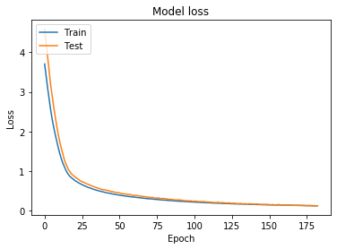

```python
# Plot training & validation loss values
plt.plot(history_2.history['loss'])
plt.plot(history_2.history['val_loss'])
plt.title('Model loss')
plt.ylabel('Loss')
plt.xlabel('Epoch')
plt.legend(['Train', 'Test'], loc='upper left')
```

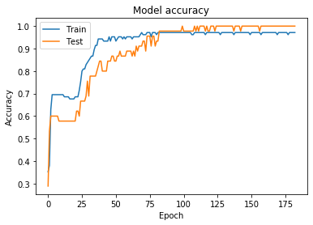

```python
# Plot training & validation accuracy values
plt.plot(history_2.history['acc'])
plt.plot(history_2.history['val_acc'])
plt.title('Model accuracy')
plt.ylabel('Accuracy')
plt.xlabel('Epoch')
plt.legend(['Train', 'Test'], loc='upper left')
```

**more detailed evaluation using model.predict and confusion matrix**

```python
from sklearn.metrics import classification_report, confusion_matrix
#from numpy import argmax
# make prediction
y_pred = model.predict(X_test)
# round predictions
y_pred_rounded = np.round(y_pred, 0) # 0 Nachkommastellen
# reverse encoder transformation to get right format for confusion_matrix function
y_pred_rounded_eva = np.argmax(y_pred_rounded, axis=1)
y_test = np.argmax(y_test, axis=1)
# confucision matrix
c_matrix = confusion_matrix(y_test,y_pred_rounded_eva)
print(c_matrix)
# classification report
clf_report = classification_report(y_test,y_pred_rounded_eva)
print(clf_report)
```

[output not shown]

#### 4.2.3 Fit the final model

**which variabels represent the full data best? - X_train + X_test, y_train + y_test**  
**final evaluation/prediction with validation data**

```python
# call the function to fit to the data (training the data)
model = baseline_model()
model.fit(X_train, y_train, epochs=100, batch_size=10)
```

## X. Make Prediction

**before making a predicition it is important to know how your used data looks like**

1. Data for prediction is the same as used for training
2. Data for prediction is different from data used in training (e.g. other features, not transformed, ...)

### X.1 Make Prediction based on the activation function

sigmoid for binary classification problems -> range between 0 and 1  
softmax for multi-class classification problems -> range between 0 and 1

```python
# make probability predictions with the model
predictions = model.predict(X)
```

### X.2 Make Prediction based on last activation function and round it to get binary predictions

```python
# round predictions
y_pred_rounded = np.round(y_pred, 0) # 0 Nachkommastellen
```

### X.3 Make Prediction for classes directly

```python
# make class predictions with the model
predictions = model.predict_classes(X)
```

### X.4 Transform original data to the needed input of the classifier

With use if pipelines

## Y. Save or Load Model

### Y.1 Save Model

```python
model.save_weights('model.h5')
```

### Y.2 Load Model

```python
# Load the model's saved weights.
model.load_weights('model.h5')
```